# 0_2-OpenDataSets

```python
# Create a "my_list" column which is made of a list with six values (i.e., 1, 2, 3, 4, 5, 6).

movies['my_list'] = [[1, 2, 3, 4, 5, 6]]*250
movies.head()
```

|  | Title | Year | Rated | Released | Runtime | Genre | Director | Writer | Actors | Plot | ... | tomatoUserMeter | tomatoUserRating | tomatoUserReviews | tomatoURL | DVD | BoxOffice | Production | Website | Response | my_list |
| --- | --- | --- | --- | --- | --- | --- | --- | --- | --- | --- | --- | --- | --- | --- | --- | --- | --- | --- | --- | --- | --- |
| 1 | The Shawshank Redemption | 1994 | R | 14 Oct 1994 | 142 min | Crime, Drama | Frank Darabont | Stephen King (short story "Rita Hayworth and Shawshank Redemption"), Frank Darabont (screenplay) | Tim Robbins, Morgan Freeman, Bob Gunton, William Sadler | Two imprisoned men bond over a number of years, finding solace and eventual redemption through acts of common decency. | ... | NaN | NaN | NaN | http://www.rottentomatoes.com/m/shawshank_redemption/ | 27 Jan 1998 | NaN | Columbia Pictures | NaN | True | [1, 2, 3, 4, 5, 6] |
| 2 | The Godfather | 1972 | R | 24 Mar 1972 | 175 min | Crime, Drama | Francis Ford Coppola | Mario Puzo (screenplay), Francis Ford Coppola (screenplay), Mario Puzo (novel) | Marlon Brando, Al Pacino, James Caan, Richard S. Castellano | The aging patriarch of an organized crime dynasty transfers control of his clandestine empire to his reluctant son. | ... | NaN | NaN | NaN | http://www.rottentomatoes.com/m/godfather/ | 09 Oct 2001 | NaN | Paramount Pictures | http://www.thegodfather.com | True | [1, 2, 3, 4, 5, 6] |
| 3 | The Godfather: Part II | 1974 | R | 20 Dec 1974 | 202 min | Crime, Drama | Francis Ford Coppola | Francis Ford Coppola (screenplay), Mario Puzo (screenplay), Mario Puzo (novel) | Al Pacino, Robert Duvall, Diane Keaton, Robert De Niro | The early life and career of Vito Corleone in 1920s New York is portrayed while his son, Michael, expands and tightens his grip on the family crime syndicate. | ... | NaN | NaN | NaN | http://www.rottentomatoes.com/m/godfather_part_ii/ | 24 May 2005 | NaN | Paramount Pictures | http://www.thegodfather.com/ | True | [1, 2, 3, 4, 5, 6] |
| 4 | The Dark Knight | 2008 | PG-13 | 18 Jul 2008 | 152 min | Action, Crime, Drama | Christopher Nolan | Jonathan Nolan (screenplay), Christopher Nolan (screenplay), Christopher Nolan (story), David S. Goyer (story), Bob Kane (characters) | Christian Bale, Heath Ledger, Aaron Eckhart, Michael Caine | When the menace known as the Joker emerges from his mysterious past, he wreaks havoc and chaos on the people of Gotham, the Dark Knight must accept one of the greatest psychological and physical tests… | ... | NaN | NaN | NaN | http://www.rottentomatoes.com/m/the_dark_knight/ | 09 Dec 2008 | $533,316,061 | Warner Bros. Pictures/Legendary | http://thedarkknight.warnerbros.com/ | True | [1, 2, 3, 4, 5, 6] |
| 5 | 12 Angry Men | 1957 | APPROVED | 01 Apr 1957 | 96 min | Crime, Drama | Sidney Lumet | Reginald Rose (story), Reginald Rose (screenplay) | Martin Balsam, John Fiedler, Lee J. Cobb, E.G. Marshall | A jury holdout attempts to prevent a miscarriage of justice by forcing his colleagues to reconsider the evidence. | ... | NaN | NaN | NaN | http://www.rottentomatoes.com/m/1000013-12_angry_men/ | 06 Mar 2001 | NaN | Criterion Collection | http://www.criterion.com/films/27871-12-angry-men | True | [1, 2, 3, 4, 5, 6] |

5 rows × 38 columns

```python
# We can set precision of numbers

pd.set_option('precision', 3)
# movies['imdbVotes'] = float (movies[['imdbVotes']].head().replace(',', ''))
# TypeError: float() argument must be a string or a number, not 'DataFrame'

#movies[['imdbVotes']].head(10)
```

```python
# adding more decimal places to imdbVotes column

print(type('aaa'))

print(movies['imdbVotes'].head())

print(type(movies['imdbVotes']))
```

```
<class 'str'>
1    1,825,626
2    1,243,444
3      856,870
4    1,802,351
5      494,215
Name: imdbVotes, dtype: object
<class 'pandas.core.series.Series'>
```

```python
# We will find an error when we execute the following script ... find out the error type
# movites_try = pd.read_csv("IMDB_Top250Engmovies2_OMDB_Detailed.csv", dtype = {"imdbVotes": "float64"})
```

```python
movies = pd.read_csv("IMDB_Top250Engmovies2_OMDB_Detailed.csv")
df = pd.DataFrame(data=movies)

# print(df['imdbVotes'] is df.imdbVotes)

df.imdbVotes.head()
```

```
0    1,825,626
1    1,243,444
2      856,870
3    1,802,351
4      494,215
Name: imdbVotes, dtype: object
```

```python
# The shape attribute for numpy arrays returns the dimensions of the array. If Y has n rows and m columns,
# then Y.shape is (n,m). So Y.shape[0] is n.
# Focusing on the ImdbVotes variable (a string), we attemt to remove the comma and turn the variable type to floating
# 这里apply()函数传入一个函数,将对Series中的每个项调用该函数

# df['imdbVotes']=df['imdbVotes'].apply(lambda x:x.replace(',', '')).astype('float')
# df['imdbVotes'].head()
```

```python
movies = pd.read_csv("IMDB_Top250Engmovies2_OMDB_Detailed.csv")
df = pd.DataFrame(data=movies)

# The shape attribute for numpy arrays returns the dimensions of the array. If Y has n rows and m columns,
# then Y.shape is (n,m). So Y.shape[0] is n.

for i in range(df.shape[0]):
    df.loc[i, 'imdbVotes']=df.loc[i, 'imdbVotes'].replace(',', '')

df['imdbVotes']=df['imdbVotes'].astype('float64')

df['imdbVotes'].head()
```

```
0    1.826e+06
1    1.243e+06
2    8.569e+05
3    1.802e+06
4    4.942e+05
Name: imdbVotes, dtype: float64
```

```python
df['imdbVotes'].mean(axis=0)
```

```
431401.324
```

```python
print(df["imdbVotes"].mean())  # An alternative way to calculate the mean for the variable 'imdbVotes'
```

```
431401.324
```

```python
# Let's create two additional variables： f1 and f2

df['f1'] = df['imdbVotes'] + 0.001

df['f2'] = movies['imdbVotes'] + 100000.001

print(df['f1'].mean())
print(df['f2'].mean())
```

```
431401.32500000007
531401.325
```

```python
# The following code can show us all the data, but please be aware of the lenghty details if the file contains a lot of data
# print(df)
```

```python
changes = df['imdbVotes'].pct_change()
print(changes.head(10))

# this percent change calculation is not adequate (why?)
```

```
0      NaN
1   -0.319
2   -0.311
3    1.103
4   -0.726
5    0.898
6    0.391
7    0.094
8    0.022
9   -0.090
Name: imdbVotes, dtype: float64
```

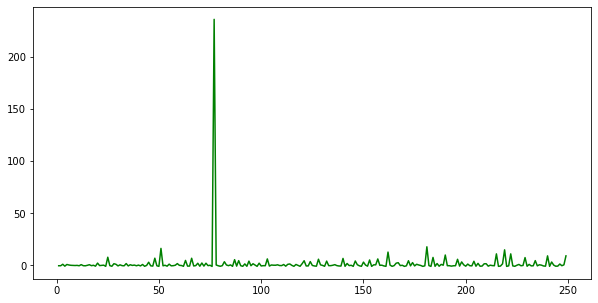

```python
import matplotlib.pyplot as plot
plot.style.use('tableau-colorblind10')
df['imdbVotes'].pct_change().plot(figsize=(10,5), color='green')
plot.show()
# such a calculation is questionable (Why? We will discuss and reveal it in class)
```

```python
'''FYI only
N1 = input('Please enter first floating point value:\n')
N1 = float(N1)

N2 = input('Please enter second floating point value:\n')
N2 = float(N2)

print(f'Sum of {N1} and {N2} is {N1+N2}')

'''
```

```
"FYI only\nN1 = input('Please enter first floating point value:\n')\nN1 = float(N1)\n\nN2 = input('Please enter second floating point value:\n')\nN2 = float(N2)\n\nprint(f'Sum of {N1} and {N2} is {N1+N2}')\n\n"
```

```python
# initializing string
s = "100"
type(s)
```

```
str
```

```python
# printing string converting to float
f = float(s)
type(f)
```

```
float
```

```python
print(f)
```

```
100.0
```

```python
current_time = pd.Timestamp.now()
print(current_time)
```

```
2020-07-05 06:50:12.648097
```

```python
# We can nest a try to throw an exception when it's not convertible to float
import pandas as pd
movies = pd.read_csv("IMDB_Top250Engmovies2_OMDB_Detailed.csv")

df = pd.DataFrame(data=movies)
df.head()
```

|  | Unnamed: 0 | Title | Year | Rated | Released | Runtime | Genre | Director | Writer | Actors | ... | tomatoConsensus | tomatoUserMeter | tomatoUserRating | tomatoUserReviews | tomatoURL | DVD | BoxOffice | Production | Website | Response |
| --- | --- | --- | --- | --- | --- | --- | --- | --- | --- | --- | --- | --- | --- | --- | --- | --- | --- | --- | --- | --- | --- |
| 0 | 1 | The Shawshank Redemption | 1994 | R | 14 Oct 1994 | 142 min | Crime, Drama | Frank Darabont | Stephen King (short story "Rita Hayworth and Shawshank Redemption"), Frank Darabont (screenplay) | Tim Robbins, Morgan Freeman, Bob Gunton, William Sadler | ... | NaN | NaN | NaN | NaN | http://www.rottentomatoes.com/m/shawshank_redemption/ | 27 Jan 1998 | NaN | Columbia Pictures | NaN | True |
| 1 | 2 | The Godfather | 1972 | R | 24 Mar 1972 | 175 min | Crime, Drama | Francis Ford Coppola | Mario Puzo (screenplay), Francis Ford Coppola (screenplay), Mario Puzo (novel) | Marlon Brando, Al Pacino, James Caan, Richard S. Castellano | ... | NaN | NaN | NaN | NaN | http://www.rottentomatoes.com/m/godfather/ | 09 Oct 2001 | NaN | Paramount Pictures | http://www.thegodfather.com | True |
| 2 | 3 | The Godfather: Part II | 1974 | R | 20 Dec 1974 | 202 min | Crime, Drama | Francis Ford Coppola | Francis Ford Coppola (screenplay), Mario Puzo (screenplay), Mario Puzo (novel) | Al Pacino, Robert Duvall, Diane Keaton, Robert De Niro | ... | NaN | NaN | NaN | NaN | http://www.rottentomatoes.com/m/godfather_part_ii/ | 24 May 2005 | NaN | Paramount Pictures | http://www.thegodfather.com/ | True |
| 3 | 4 | The Dark Knight | 2008 | PG-13 | 18 Jul 2008 | 152 min | Action, Crime, Drama | Christopher Nolan | Jonathan Nolan (screenplay), Christopher Nolan (screenplay), Christopher Nolan (story), David S. Goyer (story), Bob Kane (characters) | Christian Bale, Heath Ledger, Aaron Eckhart, Michael Caine | ... | NaN | NaN | NaN | NaN | http://www.rottentomatoes.com/m/the_dark_knight/ | 09 Dec 2008 | $533,316,061 | Warner Bros. Pictures/Legendary | http://thedarkknight.warnerbros.com/ | True |
| 4 | 5 | 12 Angry Men | 1957 | APPROVED | 01 Apr 1957 | 96 min | Crime, Drama | Sidney Lumet | Reginald Rose (story), Reginald Rose (screenplay) | Martin Balsam, John Fiedler, Lee J. Cobb, E.G. Marshall | ... | NaN | NaN | NaN | NaN | http://www.rottentomatoes.com/m/1000013-12_angry_men/ | 06 Mar 2001 | NaN | Criterion Collection | http://www.criterion.com/films/27871-12-angry-men | True |

5 rows × 38 columns

```python
pd.Timedelta('2 days 2 hours 15 minutes 30 seconds')

# td = pd.Series([pd.Timedelta(Released=i) for i in range(3)])
# df
# print(day)
```

```
Timedelta('2 days 02:15:30')
```

```python
df['Released'].dtype
```

```
dtype('O')
```

```python
# convert the dates to a TimeSeries object in Pandas
df['Released'] = pd.to_datetime(df['Released'])
df.index = df['Released']
df.head()

## #pd.date_range is a built-in time series function (#pd.date_range是內建的日期序列產生器)
```

| Released | Unnamed: 0 | Title | Year | Rated | Released | Runtime | Genre | Director | Writer | Actors | ... | tomatoConsensus | tomatoUserMeter | tomatoUserRating | tomatoUserReviews | tomatoURL | DVD | BoxOffice | Production | Website | Response |
| --- | --- | --- | --- | --- | --- | --- | --- | --- | --- | --- | --- | --- | --- | --- | --- | --- | --- | --- | --- | --- | --- |
| 1994-10-14 | 1 | The Shawshank Redemption | 1994 | R | 1994-10-14 | 142 min | Crime, Drama | Frank Darabont | Stephen King (short story "Rita Hayworth and Shawshank Redemption"), Frank Darabont (screenplay) | Tim Robbins, Morgan Freeman, Bob Gunton, William Sadler | ... | NaN | NaN | NaN | NaN | http://www.rottentomatoes.com/m/shawshank_redemption/ | 27 Jan 1998 | NaN | Columbia Pictures | NaN | True |
| 1972-03-24 | 2 | The Godfather | 1972 | R | 1972-03-24 | 175 min | Crime, Drama | Francis Ford Coppola | Mario Puzo (screenplay), Francis Ford Coppola (screenplay), Mario Puzo (novel) | Marlon Brando, Al Pacino, James Caan, Richard S. Castellano | ... | NaN | NaN | NaN | NaN | http://www.rottentomatoes.com/m/godfather/ | 09 Oct 2001 | NaN | Paramount Pictures | http://www.thegodfather.com | True |
| 1974-12-20 | 3 | The Godfather: Part II | 1974 | R | 1974-12-20 | 202 min | Crime, Drama | Francis Ford Coppola | Francis Ford Coppola (screenplay), Mario Puzo (screenplay), Mario Puzo (novel) | Al Pacino, Robert Duvall, Diane Keaton, Robert De Niro | ... | NaN | NaN | NaN | NaN | http://www.rottentomatoes.com/m/godfather_part_ii/ | 24 May 2005 | NaN | Paramount Pictures | http://www.thegodfather.com/ | True |
| 2008-07-18 | 4 | The Dark Knight | 2008 | PG-13 | 2008-07-18 | 152 min | Action, Crime, Drama | Christopher Nolan | Jonathan Nolan (screenplay), Christopher Nolan (screenplay), Christopher Nolan (story), David S. Goyer (story), Bob Kane (characters) | Christian Bale, Heath Ledger, Aaron Eckhart, Michael Caine | ... | NaN | NaN | NaN | NaN | http://www.rottentomatoes.com/m/the_dark_knight/ | 09 Dec 2008 | $533,316,061 | Warner Bros. Pictures/Legendary | http://thedarkknight.warnerbros.com/ | True |
| 1957-04-01 | 5 | 12 Angry Men | 1957 | APPROVED | 1957-04-01 | 96 min | Crime, Drama | Sidney Lumet | Reginald Rose (story), Reginald Rose (screenplay) | Martin Balsam, John Fiedler, Lee J. Cobb, E.G. Marshall | ... | NaN | NaN | NaN | NaN | http://www.rottentomatoes.com/m/1000013-12_angry_men/ | 06 Mar 2001 | NaN | Criterion Collection | http://www.criterion.com/films/27871-12-angry-men | True |

5 rows × 38 columns

```python
del df['Released']
df.head()
```

| Released | Unnamed: 0 | Title | Year | Rated | Runtime | Genre | Director | Writer | Actors | Plot | ... | tomatoConsensus | tomatoUserMeter | tomatoUserRating | tomatoUserReviews | tomatoURL | DVD | BoxOffice | Production | Website | Response |
| --- | --- | --- | --- | --- | --- | --- | --- | --- | --- | --- | --- | --- | --- | --- | --- | --- | --- | --- | --- | --- | --- |
| 1994-10-14 | 1 | The Shawshank Redemption | 1994 | R | 142 min | Crime, Drama | Frank Darabont | Stephen King (short story "Rita Hayworth and Shawshank Redemption"), Frank Darabont (screenplay) | Tim Robbins, Morgan Freeman, Bob Gunton, William Sadler | Two imprisoned men bond over a number of years, finding solace and eventual redemption through acts of common decency. | ... | NaN | NaN | NaN | NaN | http://www.rottentomatoes.com/m/shawshank_redemption/ | 27 Jan 1998 | NaN | Columbia Pictures | NaN | True |
| 1972-03-24 | 2 | The Godfather | 1972 | R | 175 min | Crime, Drama | Francis Ford Coppola | Mario Puzo (screenplay), Francis Ford Coppola (screenplay), Mario Puzo (novel) | Marlon Brando, Al Pacino, James Caan, Richard S. Castellano | The aging patriarch of an organized crime dynasty transfers control of his clandestine empire to his reluctant son. | ... | NaN | NaN | NaN | NaN | http://www.rottentomatoes.com/m/godfather/ | 09 Oct 2001 | NaN | Paramount Pictures | http://www.thegodfather.com | True |
| 1974-12-20 | 3 | The Godfather: Part II | 1974 | R | 202 min | Crime, Drama | Francis Ford Coppola | Francis Ford Coppola (screenplay), Mario Puzo (screenplay), Mario Puzo (novel) | Al Pacino, Robert Duvall, Diane Keaton, Robert De Niro | The early life and career of Vito Corleone in 1920s New York is portrayed while his son, Michael, expands and tightens his grip on the family crime syndicate. | ... | NaN | NaN | NaN | NaN | http://www.rottentomatoes.com/m/godfather_part_ii/ | 24 May 2005 | NaN | Paramount Pictures | http://www.thegodfather.com/ | True |
| 2008-07-18 | 4 | The Dark Knight | 2008 | PG-13 | 152 min | Action, Crime, Drama | Christopher Nolan | Jonathan Nolan (screenplay), Christopher Nolan (screenplay), Christopher Nolan (story), David S. Goyer (story), Bob Kane (characters) | Christian Bale, Heath Ledger, Aaron Eckhart, Michael Caine | When the menace known as the Joker emerges from his mysterious past, he wreaks havoc and chaos on the people of Gotham, the Dark Knight must accept one of the greatest psychological and physical tests… | ... | NaN | NaN | NaN | NaN | http://www.rottentomatoes.com/m/the_dark_knight/ | 09 Dec 2008 | $533,316,061 | Warner Bros. Pictures/Legendary | http://thedarkknight.warnerbros.com/ | True |
| 1957-04-01 | 5 | 12 Angry Men | 1957 | APPROVED | 96 min | Crime, Drama | Sidney Lumet | Reginald Rose (story), Reginald Rose (screenplay) | Martin Balsam, John Fiedler, Lee J. Cobb, E.G. Marshall | A jury holdout attempts to prevent a miscarriage of justice by forcing his colleagues to reconsider the evidence. | ... | NaN | NaN | NaN | NaN | http://www.rottentomatoes.com/m/1000013-12_angry_men/ | 06 Mar 2001 | NaN | Criterion Collection | http://www.criterion.com/films/27871-12-angry-men | True |

5 rows × 37 columns

```python
df.index.dtype
# dtype('<M8[ns]') refers to a time series (dtype('<M8[ns]') 是表示时间的数据类型； https://www.codeleading.com/article/26792205230/)
```

```
dtype('<M8[ns]')
```

```python
# print(df)
# export the contents of the dataframe to a Stata data file

df.to_stata('try1.dta', version=118)
```

[output not shown]

```python
# Matplotlib is the standard plotting package in Python. Check https://matplotlib.org/tutorials/introductory/pyplot.html#sphx-glr-tutorials-introductory-pyplot-py.

import matplotlib.pyplot as plot
print(plot.style.available)
```

[output not shown]

```python
# Error messages (earlier attempt to convert string to a floating format)
'''
df = pd.DataFrame(movies)

df[['imdbVotes']] = df[['imdbVotes']].astype({'imdbVotes':'float64'})

# df[['imdbVotes']] = df[['imdbVotes']].astype('float')

# df['imdbVotes'] = df.imdbVotes.replace('', np.nan).astype('float64')

print(df['imdbVotes']) '''
```

```
"\ndf = pd.DataFrame(movies)\n\ndf[['imdbVotes']] = df[['imdbVotes']].astype({'imdbVotes':'float64'})\n\n# df[['imdbVotes']] = df[['imdbVotes']].astype('float')\n\n# df['imdbVotes'] = df.imdbVotes.replace('', np.nan).astype('float64')\n\nprint(df['imdbVotes']) "
```

```python
"""
movies = pd.read_csv('IMDB_Top250Engmovies2_OMDB_Detailed.csv')
df = pd.DataFrame(data=movies)

for i in range(df.shape[0]):
    df['imdbVotes'][i]=df['imdbVotes'][i].replace(',', '')

df['imdbVotes']=df['imdbVotes'].astype('float64')  """
```

```
"\nmovies = pd.read_csv('IMDB_Top250Engmovies2_OMDB_Detailed.csv')\ndf = pd.DataFrame(data=movies)\n\nfor i in range(df.shape[0]):\n    df['imdbVotes'][i]=df['imdbVotes'][i].replace(',', '')\n    \ndf['imdbVotes']=df['imdbVotes'].astype('float64')  "
```

```python
type(df['imdbVotes'])
```

```
pandas.core.series.Series
```

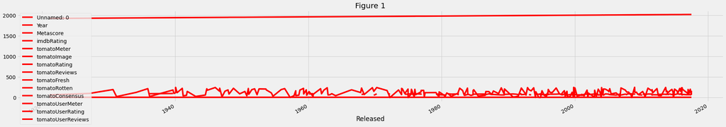

```python
plot.style.use('fivethirtyeight')
df.plot(title='Figure 1', figsize=(30,5), color='red')
plot.show()
```

## Your might feel a bit overwhelmed if you are a novice in Python. However, after reviewing this tutorial one more time, I hope you fell comfortable to import CSV file into Python with ways to clean and manage file.

## The goal is to show you how to import csv and excel files to Python. Once done, you should explore how to perform common data manipulation or wrangling tasks like filtering, selecting and renaming columns, identify and remove duplicates etc on pandas dataframe.

# Appendix

## Exercise 0_2.1

### Use scipy.stat to generate normal distribution probability density function graphs and cumulative distribution function graphs with mean of 5 and variance of 3 between 0 and 10

## Exercise 0_2.2

### Generate the following dataframe, and slice Andy's Java grades and print them out, then draw a bar chart to show the grades of different students

''' Name age python java math 0 Andy 18 90 80 100 1 Mike 17 88 89 90 2 Lucy 18 91 88 87 3 Bill 19 77 75 80 '''